# Fixing Approximations

2020-10-07

## Fixing Approximations

Assume we have a Bayesian model:

$$\begin{equation}
p(\theta \mid x) \propto p(x \mid \theta) p(\theta)
\end{equation}$$

Try as we might to make this model go fast, sometimes it just doesn’t. In fact, often it doesn’t. There are numerous reasons this might happen:

1. Difficult to sample posterior geometry
2. Bug in the code
3. Model does not fit the data well
4. Lots of data
5. etc…

The particular situation we want to discuss here is one where you are happy with your model but there are some difficult calculations you want to approximate for performance reasons.

This comes up relatively often when dealing with integrals and differential equations in Stan. Stan comes with a couple common ODE integrators and one quadrature scheme in the language itself, but if those prepackaged solutions do not work, something else must be done. Usually what happens is an approximate quadrature or integrator gets used that is much faster or more stable than the reference implementation in Stan. The question immediately becomes, how do I know my approximation is good enough?

The goal of this case study is to figure out if your approximation is good enough, and, if possible use importance sampling to correct for any bias in the results. This is using techniques from the papers (Yao et al. 2018), (Vehtari et al. 2019), and the `loo` software package (https://mc-stan.org/loo).

## 1D Diffusion Example

First, let’s start with a problem where Stan is slow.

Let’s pretend that we are modeling a 1D diffusion problem on $x \in [0, L]$ with initial concentration that is a step function at $x = L / 2$ and with fixed boundary conditions (that match the step). So that means:

$$\frac{\partial u}{\partial t} = D \frac{\partial^2 u}{\partial x^2} \\
u(t, x = 0) = 0 \\
u(t, x = L) = 1 \\
u(t = 0, x) = x > \frac{L}{2}$$

Let’s pretend that we’re going to measure the concentration of this system at time $t = T$ and try to estimate the diffusion constant.

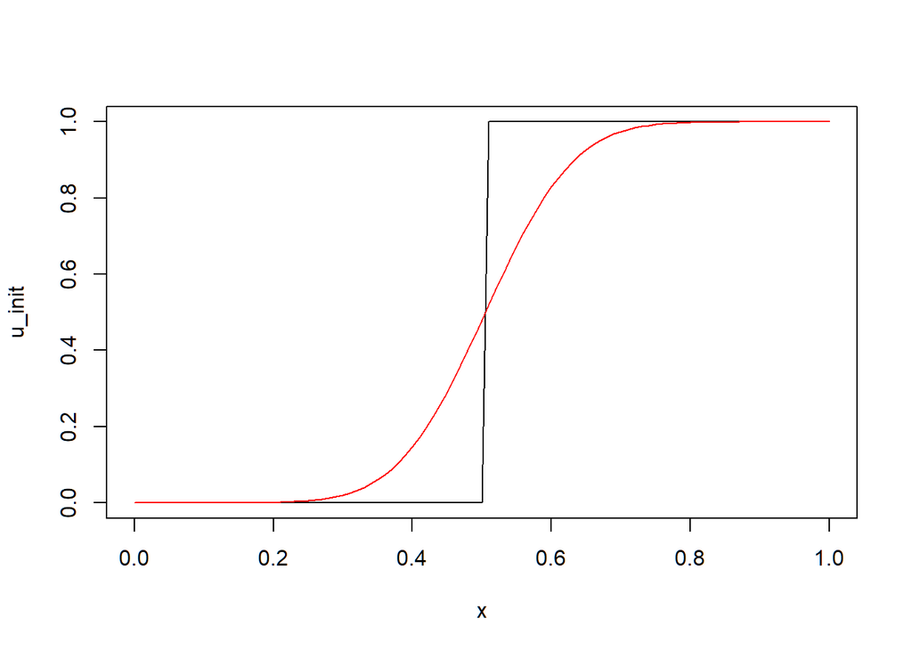

```r
L = 1
Tf = 1
D = 0.25
dx = 1e-2
dt = 1e-4

x = seq(0, 1, by = dx)
u_init = x > L / 2.0

u = u_init
for(t in seq(0, Tf, by = dt)) {
  u_new = u

  for(i in 2:(length(u) - 1)) {
    u_new[i] = dt * (u[i + 1] - 2 * u[i] + u[i - 1]) / (2 * dx) + u[i]
  }

  u = u_new
}

plot(x, u_init, type = 'l')
lines(x, u, col = 'red')
```

Now, if you’re familiar with diffusion equations you might say, ‘Oh, you fools, you’ve done a forward Euler method on a diffusion problem and you’re not even trying to control your error due to your timestep or your spatial discretization.’

Since you are this far in the case study, we will admit, yes, this is a bad way to solve the problem. We did it in a pinch because it was easier to do it this way than worry about an adaptive timestep/adaptive meshsize method. After all, we are solving a 1D diffusion. We can just make a finer discretization or use smaller timesteps and see how the error between successive approximations gets smaller.

But how should we check this in a model in Stan? The error in the solution from using an approximation is important, but really the error in the posterior is what matters. That leads to our first question

## Is the Approximation Good Enough?

Assume we have a distribution $p_{true}(\theta)$ and $p_{approx}(\theta)$.

$p_{approx}$ is meant to approximate $p_{true}$. If they have the same support then mathematically we can write expectations over $p_{true}$ as weighted expectations over $p_{approx}$.

$$E[f(\theta)] = \int f(\theta) p_{true}(\theta)\\
= \int f(\theta) \frac{p_{true}(\theta)}{p_{approx}(\theta)}p_{approx}(\theta)d\theta$$

If we’re computing estimates with Monte Carlo, this means we replace expectations over samples from our true distribution with weighted samples from the approximate distribution.

In general, we can diagnose if the expectations will work by examing the distribution of the importance weights by using the Pareto Smooth Importance Sampling diagnostic. But first, let’s write a Stan model

## References

Vehtari, Aki, Daniel Simpson, Andrew Gelman, Yuling Yao, and Jonah Gabry. 2019. “Pareto Smoothed Importance Sampling.” http://arxiv.org/abs/1507.02646.

Yao, Yuling, Aki Vehtari, Daniel Simpson, and Andrew Gelman. 2018. “Yes, but Did It Work?: Evaluating Variational Inference.” http://arxiv.org/abs/1802.02538.